# Regional Housing Framework

Identify correct zoning designation

Library: RegHsg

Project: Regional Housing Framework

Author: Sarah Strochak

Version: R 3.5.1, RStudio 1.1.423

Last updated February 04, 2019

Environment: Local Windows session (desktop)

## Description

The purpose of this step is to test the zoning designations in the Black Knight data against the Arlington zoning code shapefile, and determine which variable should be used for analysis.

## Set-up

### Black Knight

Load libraries and functions

```r
library(tidyverse)
library(sf)

source("../Macros/read-jurisdiction.R")
```

Create directory for data exports

```r
if (!dir.exists("../Data")) {
  dir.create("../Data")
}
```

Set FIPS code and filepath name

```r
currentfips <- "51013"
filepath <- "arlington"
```

Load in Black Knight data for the region, select jurisdiction and standard variables

```r
if (!exists("jur")) {
  jur <- read_jurisdiction(filepath)
} else {
  warning(filepath, " data already read in")
}
```

### Zoning Map

First, download file if not already downloaded. Use “jurisdiction-zoning-map.zip” for consistency.

```r
zzip <- paste0("L:/Libraries/RegHsg/Maps/",
                     filepath,
                     "-zoning-map.zip")
zdir <- paste0("L:/Libraries/RegHsg/Maps/",
               filepath,
               "-zoning-map")

zurl <- "https://gisdata-arlgis.opendata.arcgis.com/datasets/28efb25252b54f1180b703fbcdd2209b_0"

if (!file.exists(zzip)) {

  download.file(zurl,
                destfile = zzip)

  dir.create(zdir)

  unzip(zzip, exdir = zdir)

}

zfile <- str_sub(list.files(zdir), end = -5) %>% unique()
```

Repeat process for parcel shapefile if not already downloaded. Use “jurisdiction-parcel-map.zip” for consistency.

```r
pdir <- paste0("L:/Libraries/RegHsg/Maps/",
               filepath,
               "-parcel-map")
pzip <- paste0("L:/Libraries/RegHsg/Maps/",
               filepath,
               "-parcel-map.zip")

purl <- "https://opendata.arcgis.com/datasets/b70198178ff44462b00c5b5c0012668d_0.zip?outSR=%7B%22wkid%22%3A102746%2C%22latestWkid%22%3A2283%7D"

if (!file.exists(pzip)) {

  download.file(purl,
                destfile = pzip)

  dir.create(pdir)

  unzip(pzip, exdir = pdir)

}

pfile <- str_sub(list.files(pdir), end = -5) %>% unique()
```

Read in files as `sf` objects.

```r
zon <- read_sf(dsn = zdir,
               layer = zfile)

par <- read_sf(dsn = pdir,
               layer = pfile)

rm(purl, pzip, pfile, pdir,
   zurl, zzip, zfile, zdir)
```

Set CRS of both files.

```r
st_geometry(zon)
```

```
## Geometry set for 614 features
## geometry type:  POLYGON
## dimension:      XY
## bbox:           xmin: 11860790 ymin: 6987492 xmax: 11900920 ymax: 7026257
## epsg (SRID):    NA
## proj4string:    +proj=lcc +lat_1=38.03333333333333 +lat_2=39.2 +lat_0=37.66666666666666 +lon_0=-78.5 +x_0=3499999.999999999 +y_0=2000000 +datum=NAD83 +units=us-ft +no_defs
## First 5 geometries:
```

```r
zon <- st_transform(zon, crs = 4326)
par <- st_transform(par, crs = 4326)
```

Quick map for each to make sure they read in correctly.

##### zoning map

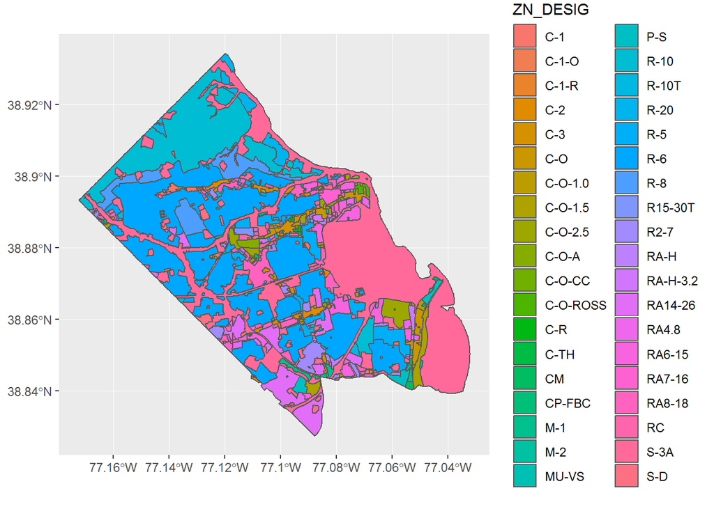

```r
ggplot(zon) +
  geom_sf(mapping = aes(fill = ZN_DESIG))
```

##### parcel map

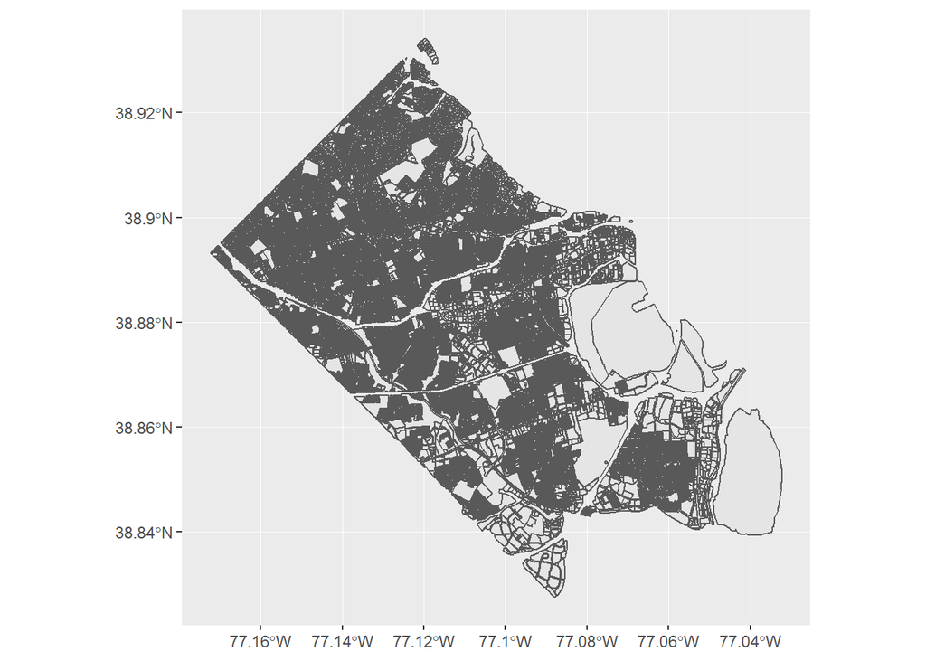

```r
ggplot(par) +
  geom_sf(mapping = aes())
```

## Map vacant parcels

First, check CRS of zoning map.

```r
st_geometry(zon)
```

```
## Geometry set for 614 features
## geometry type:  POLYGON
## dimension:      XY
## bbox:           xmin: -77.17231 ymin: 38.82747 xmax: -77.03217 ymax: 38.9343
## epsg (SRID):    4326
## proj4string:    +proj=longlat +datum=WGS84 +no_defs
## First 5 geometries:
```

```r
zon <- st_transform(zon, crs = 4326)
```

Filter out only the parcels that are vacant

```r
vacant <- jur %>%
  filter(category == "vacant")

vacant %>% count(address_type)
```

```
## # A tibble: 3 x 2
##   address_type     n
##   <chr>        <int>
## 1 missing       1610
## 2 multiple       129
## 3 single         536
```

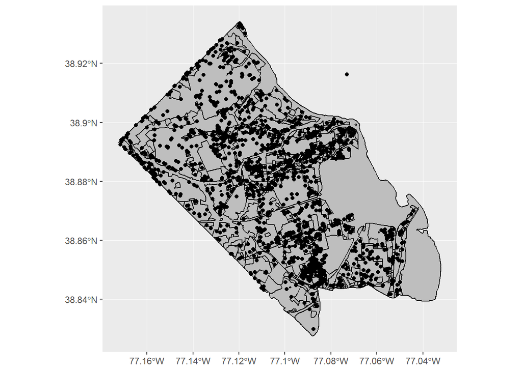

```r
vacantsf <- vacant %>%
  filter(!is.na(long), !is.na(lat)) %>%
  st_as_sf(coords = c("long", "lat")) %>%
  st_set_crs(st_crs(zon))


ggplot() +
  geom_sf(data = zon, mapping = aes(),
          fill = "grey", color = "black") +
  geom_sf(data = vacantsf, mapping = aes())
```

Spatial join

```r
x <- st_join(vacantsf, zon)

count(x, is.na(ZN_DESIG))
```

```
## Simple feature collection with 2 features and 2 fields
## geometry type:  MULTIPOINT
## dimension:      XY
## bbox:           xmin: -77.17156 ymin: 38.82991 xmax: -77.04395 ymax: 38.93338
## epsg (SRID):    4326
## proj4string:    +proj=longlat +datum=WGS84 +no_defs
## # A tibble: 2 x 3
##   `is.na(ZN_DESIG)`     n                                         geometry
##   <lgl>             <int>                                <MULTIPOINT [Â°]>
## 1 FALSE              1970 (-77.17126 38.89403, -77.17099 38.89345, -77.17~
## 2 TRUE                 11 (-77.17156 38.8924, -77.15722 38.88125, -77.156~
```

```r
count(x, ZN_DESIG == zoning)
```

```
## Simple feature collection with 3 features and 2 fields
## geometry type:  MULTIPOINT
## dimension:      XY
## bbox:           xmin: -77.17156 ymin: 38.82991 xmax: -77.04395 ymax: 38.93338
## epsg (SRID):    4326
## proj4string:    +proj=longlat +datum=WGS84 +no_defs
## # A tibble: 3 x 3
##   `ZN_DESIG == zoni~     n                                        geometry
##   <lgl>              <int>                               <MULTIPOINT [Â°]>
## 1 FALSE                548 (-77.17033 38.89461, -77.16883 38.89497, -77.1~
## 2 TRUE                1348 (-77.17126 38.89403, -77.17099 38.89345, -77.1~
## 3 NA                    85 (-77.17156 38.8924, -77.1638 38.88794, -77.157~
```

```r
test_zoning <- x %>%
  mutate(zflag = ifelse(ZN_DESIG == zoning,
                        0,
                        1)) %>%
  filter(zflag == 1) %>%
  select(propaddress, zoning, ZN_DESIG,
         category_detail, geometry)
```

Test with more than just vacant properties

```r
jursf <- jur %>%
  filter(!is.na(long), !is.na(lat)) %>%
  st_as_sf(coords = c("long", "lat")) %>%
  st_set_crs(st_crs(zon))


y <- st_join(jursf, zon)

count(y, is.na(ZN_DESIG))
```

```
## Simple feature collection with 2 features and 2 fields
## geometry type:  MULTIPOINT
## dimension:      XY
## bbox:           xmin: -77.17167 ymin: 38.82772 xmax: -77.04395 ymax: 38.93368
## epsg (SRID):    4326
## proj4string:    +proj=longlat +datum=WGS84 +no_defs
## # A tibble: 2 x 3
##   `is.na(ZN_DESIG)`     n                                         geometry
##   <lgl>             <int>                                <MULTIPOINT [Â°]>
## 1 FALSE             41717 (-77.17167 38.89358, -77.17153 38.89331, -77.17~
## 2 TRUE                 17 (-77.17156 38.8924, -77.15722 38.88125, -77.156~
```

```r
test_all <- y %>%
  mutate(zflag = ifelse(ZN_DESIG == zoning,
                        0,
                        1)) %>%
  filter(zflag == 1) %>%
  select(propaddress, zoning, ZN_DESIG,
         category_detail, geometry)
```